# Sensitivity analyses

Esin Ickin, Chloé Nater

5/04/2023

This code is an implementation of Esin’s template for Nater et al.’s study on arctic foxes. The data files needed for running the code below, as well as the original files from which the code below is taken, have been deposited in a folder “Files_ArcticFox” within the repository. Questions about details of the study and/or code in sections 1-3 below can be sent to chloe.nater@nina.no.

## 1) Vital rates

The following estimates and code are from a papers on Arctic foxes (Alopex lagopus) from Svalbard: https://doi.org/10.1002/ecs2.3546

The study simultaneously estimated vital rates as functions of three environmental covariates (sea ice extent, availability of reindeer carcasses, and goose population size) and population dynamics using an Integrated Population Model (conveniently also abbreviated “IPM”).

Like most integrated analyses, the model has been implemented in a Bayesian framework, meaning that a) all parameter estimates are stored as posterior distributions and b) all vital rate prediction functions are custom-made.

```r
library(coda)

load("Files_ArcticFox/ArcticFox_IPM_PosteriorSamples.RData")
out.data <- reshape2::melt(as.matrix(MCMCsamples))

out.sum <- out.data %>%
  dplyr::group_by(Var2) %>%
  dplyr::summarise(Median = median(value),
                   lower_90CI = quantile(value, probs = 0.05),
                   upper_90CI = quantile(value, probs = 0.95),
                   Mean = mean(value),
                   SD = sd(value)) %>%
  dplyr::rename(Parameter = Var2)

saveRDS(out.sum, file = "Files_ArcticFox/ArcticFoxIPM_PosteriorSummary.rds")
```

You will find an explanation of all variable names in the model code (“ArcticFox_IPM.R”) which I have added to “Files_ArcticFox”.

Below is code used for making vital rate predictions based on enviornmental covariates. The vital rates that get predictions are pregnancy rate (Psi), litter size in utero (rho), survival from birth to emergence from den (s0), and natural mortality (mO). The final vital rate, harvest mortality (mH), was modelled for two time periods but not as a function of covariates (see implementation of matrix model below).

The prediction function below lets one specify which vital rate to make predictions for. It currently works on posterior samples, so you’ll need to download those from the article supplementary to make it work. Note that the function also makes predictions over a plausible range of z-standardized covariate values, not just for a single value. So that is not quite what you need yet, but it contains everything you need to write additional functions that calculate vital rates for a specific combination of covariate values (either using posterior samples, or a posterior summary such as the median).

The function inputs are a matrix of posterior samples (`MCMC.mat`), a string called `effect` that specifies the covariate to make predictions for, and an integer `RepAgeClass` which determines which age class the vital rate predictions should apply to. Age class 1 represents young of the year, age classes 2, 3, 4, and 5 represents adult foxes aged 1, 2, 3, and 4+ years.

```r
library(coda)
## Making vital rate predictions depending on (standardized) env. covariates

# Load posterior samples
load("Files_ArcticFox/ArcticFox_IPM_PosteriorSamples.RData")

# Re-structure into matrix
MCMC.mat <- as.matrix(MCMCsamples)

# Set prediction range
SDcov <- seq(-2.5, 2.5, length.out = 100)

cov.predict <- function(MCMC.mat, effect, RepAgeClass){

  # Prepare data frames
  Psi.pred <- rho.pred <- mO.pred <- S0.pred <- data.frame(SDcov = SDcov, median = rep(NA, length(SDcov)), lCI = rep(NA, length(SDcov)), uCI = rep(NA, length(SDcov)), Covariate = effect)

  Psi.pred$VitalRate <- 'Pregnancy rate'
  rho.pred$VitalRate <- 'Fetus number'
  mO.pred$VitalRate <- 'Natural mortality'
  S0.pred$VitalRate <- 'Denning survival'

  # Set effect sizes
  if(effect == 'RdCarcass'){
    beta.Psi <- MCMC.mat[,"betaRC.Psi"]
    beta.rho <- MCMC.mat[,"betaRC.rho"]
    beta.mO <- MCMC.mat[,"betaRC.mO"]
    beta.m0 <- MCMC.mat[,"betaRC.m0"]
  }

  if(effect == 'SeaIce'){
    beta.Psi <- MCMC.mat[,"betaSI.Psi"]
    beta.rho <- MCMC.mat[,"betaSI.rho"]
    beta.mO <- MCMC.mat[,"betaSI.mO"]
    beta.m0 <- MCMC.mat[,"betaSI.m0"]
  }

  if(effect == 'Goose'){
    beta.Psi <- 0
    beta.rho <- 0
    beta.mO <- MCMC.mat[,"betaG.mO"]
    beta.m0 <- 0
  }


  # Make predictions
  for(i in 1:length(SDcov)){

    # Pregnacy rate
    eta <- plogis(MCMC.mat[,"par.b"]*(MCMC.mat[,"par.c"] - RepAgeClass) + beta.Psi*SDcov[i])
    Psi <- MCMC.mat[,"par.a"]*eta

    Psi.pred[i,2] <- quantile(Psi, 0.5)
    Psi.pred[i,3] <- quantile(Psi, 0.05)
    Psi.pred[i,4] <- quantile(Psi, 0.95)

    # Placental scars
    rho <- exp(log(MCMC.mat[,'mean.rho']) + MCMC.mat[,'a.eff1']*RepAgeClass + beta.rho*SDcov[i])

    rho.pred[i,2] <- quantile(rho, 0.5)
    rho.pred[i,3] <- quantile(rho, 0.05)
    rho.pred[i,4] <- quantile(rho, 0.95)

    # Natural mortality
    if(effect == 'Goose'){
        mO <- exp(log(MCMC.mat[,'Mu.mO[2]']) + beta.mO*SDcov[i])
    }else{
        mO <- exp(log(MCMC.mat[,'Mu.mO[1]']) + beta.mO*SDcov[i])
    }

    mO.pred[i,2] <- quantile(mO, 0.5)
    mO.pred[i,3] <- quantile(mO, 0.05)
    mO.pred[i,4] <- quantile(mO, 0.95)

    # Denning survival
    m0 <- exp(log(-log(MCMC.mat[,'S0'])) + beta.m0*SDcov[i])
    S0 <- exp(-m0)

    S0.pred[i,2] <- quantile(S0, 0.5)
    S0.pred[i,3] <- quantile(S0, 0.05)
    S0.pred[i,4] <- quantile(S0, 0.95)

  }

  results <- rbind(Psi.pred, rho.pred, mO.pred, S0.pred)

  return(results)
}


CarcassEff <- cov.predict(MCMC.mat, 'RdCarcass', 3)
SeaIceEff <- cov.predict(MCMC.mat, 'SeaIce', 3)
GooseEff <- cov.predict(MCMC.mat, 'Goose', 3)
```

The dataframes returned by the function can then be used to plot vital rates as a function of covariates:

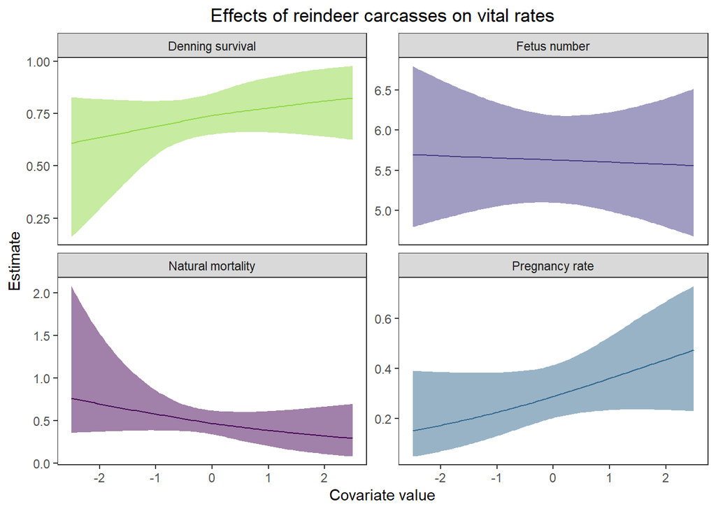

```r
library(ggplot2)
library(viridis)
ggplot(CarcassEff, aes(x = SDcov, y = median)) + geom_line(aes(color = VitalRate)) + geom_ribbon(aes(ymin = lCI, ymax = uCI, fill = VitalRate), color = NA, alpha = 0.5) + ylab('Estimate') + xlab('Covariate value') + theme_bw() + theme(panel.grid = element_blank(), legend.position = 'none', plot.title = element_text(hjust = 0.5)) + scale_color_manual(values = c(viridis(7)[6], viridis(7)[2], viridis(7)[1], viridis(7)[3])) + scale_fill_manual(values = c(viridis(7)[6], viridis(7)[2], viridis(7)[1], viridis(7)[3])) + facet_wrap(~VitalRate, scales = 'free_y') + ggtitle('Effects of reindeer carcasses on vital rates')
```

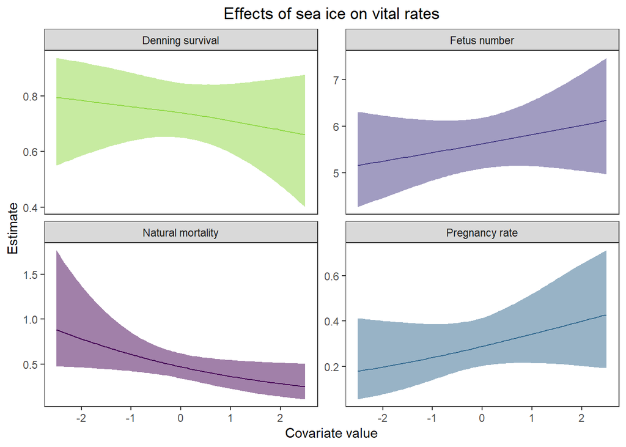

```r
ggplot(SeaIceEff, aes(x = SDcov, y = median)) + geom_line(aes(color = VitalRate)) + geom_ribbon(aes(ymin = lCI, ymax = uCI, fill = VitalRate), color = NA, alpha = 0.5) + ylab('Estimate') + xlab('Covariate value') + theme_bw() + theme(panel.grid = element_blank(), legend.position = 'none', plot.title = element_text(hjust = 0.5)) + scale_color_manual(values = c(viridis(7)[6], viridis(7)[2], viridis(7)[1], viridis(7)[3])) + scale_fill_manual(values = c(viridis(7)[6], viridis(7)[2], viridis(7)[1], viridis(7)[3])) + facet_wrap(~VitalRate, scales = 'free_y') + ggtitle('Effects of sea ice on vital rates')
```

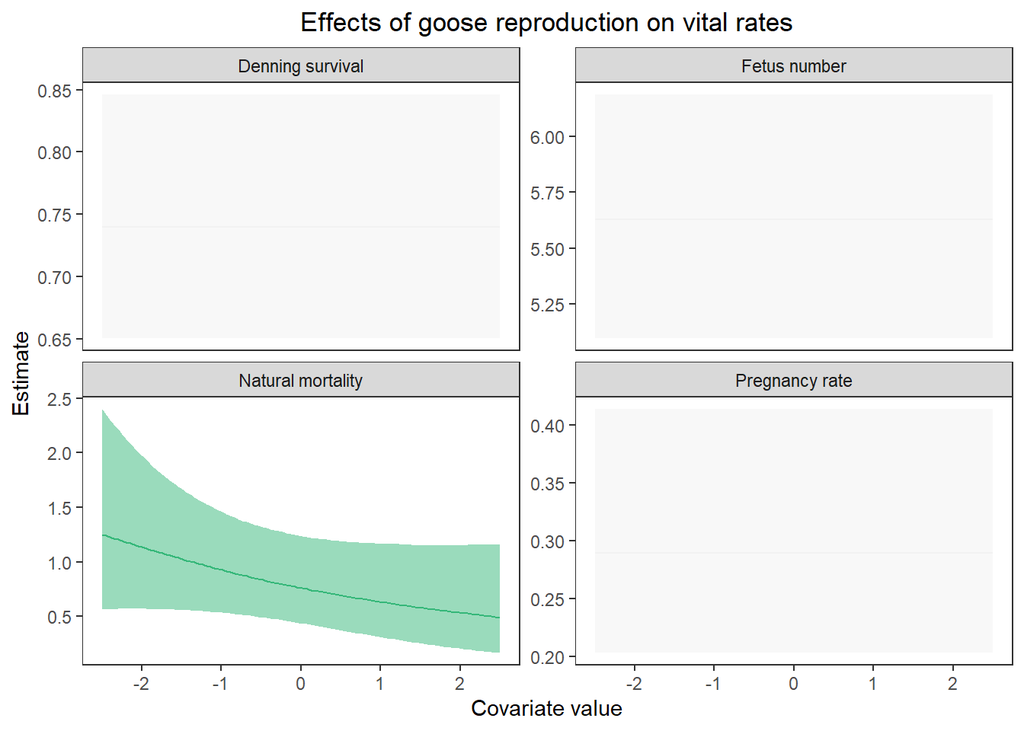

```r
ggplot(GooseEff, aes(x = SDcov, y = median)) + geom_line(aes(color = VitalRate)) + geom_ribbon(aes(ymin = lCI, ymax = uCI, fill = VitalRate), color = NA, alpha = 0.5) + ylab('Estimate') + xlab('Covariate value') + theme_bw() + theme(panel.grid = element_blank(), legend.position = 'none', plot.title = element_text(hjust = 0.5)) + scale_color_manual(values = c('grey95', 'grey95', viridis(7)[5], 'grey95')) + scale_fill_manual(values = c('grey95', 'grey95', viridis(7)[5], 'grey95')) + facet_wrap(~VitalRate, scales = 'free_y') + ggtitle('Effects of goose reproduction on vital rates')
```

## 2) Covariates

For estimating covariate effects on vital rates, covariates were de-trended and z-standardized. The de-trending was necessary because there are strong directional changes in most environmental variables on Svalbard due to climate change and without de-trending, a “general trend” would be the one signal overwhelming everything else.

Nonetheless, the input covariates for prediction functions will all have means of 0 and standard deviations of 1. In case you are interested in mapping this back onto the actual covariate values, I have added a dataframe with the de-trended time series of covariates (original and standardized).

```r
envData <- readRDS("Files_ArcticFox/ArcticFoxIPM_EnvCov.rds")
envData
```

```
##    Year RdCarcass RdCarcass_sc      SeaIce   SeaIce_sc       Goose    Goose_sc
## 1  1997 -29.07609   -0.4724457 -192.670010 -0.62087585   -907.3478 -0.12334259
## 2  1998 -20.45652   -0.3323898  446.862852  1.44000798   4432.8142  0.60258566
## 3  1999 -18.83696   -0.3060742  259.095242  0.83493003  -3827.0237 -0.52023602
## 4  2000  19.78261    0.3214397 -564.966153 -1.82059387  -1186.8617 -0.16133900
## 5  2001 -20.59783   -0.3346858 -341.499239 -1.10047552  -1246.6996 -0.16947322
## 6  2002 143.02174    2.3239030   40.220023  0.12960834  -6206.5375 -0.84370117
## 7  2003 -45.35870   -0.7370153   -3.578984 -0.01153322  -7266.3755 -0.98777288
## 8  2004 -31.73913   -0.5157164  672.051689  2.16567519  -1826.2134 -0.24825088
## 9  2005 -17.11957   -0.2781690   31.328608  0.10095591  -2086.0514 -0.28357260
## 10 2006  11.50000    0.1868589 -397.510466 -1.28097075    354.1107  0.04813692
## 11 2007 -28.88043   -0.4692666 -274.768623 -0.88543724   2294.2727  0.31187769
## 12 2008 149.73913    2.4330512 -122.646377 -0.39522587   3034.4348  0.41249346
## 13 2009 -40.64130   -0.6603643  328.873514  1.05978933   1074.5968  0.14607800
## 14 2010  25.97826    0.4221104   26.030582  0.08388311   5114.7589  0.69528751
## 15 2011 -52.40217   -0.8514620  634.957645  2.04614026  14154.9209  1.92418450
## 16 2012  52.21739    0.8484595 -231.187138 -0.74499664  13795.0830  1.87526903
## 17 2013 -37.16304   -0.6038474 -106.804637 -0.34417614   6235.2451  0.84760360
## 18 2014 -45.54348   -0.7400178 -158.076383 -0.50939847 -12724.5929 -1.72974929
## 19 2015 -37.92391   -0.6162105   99.113314  0.31939098    323.5692  0.04398518
## 20 2016 -14.30435   -0.2324256 -178.444088 -0.57503305  12355.7312  1.67960715
## 21 2017 -36.68478   -0.5960764 -134.894259 -0.43469447  -5604.1067 -0.76180823
## 22 2018 -54.06522   -0.8784841   77.691563  0.25035975  -6263.9447 -0.85150495
## 23 2019 128.55435    2.0888282   90.821326  0.29267019 -14023.7826 -1.90635788
```

## 3) Population model

While often not explicitly written out as matrices, the cores of integrated population models are typically stage-structured population models that can be formulated as an MPMs. This is also the case for this model, and the matrix formulation can be found in the main article.  
Note, however, that this is an open population model, meaning it also includes an immigration component that gets added in addition to the matrix multiplication.

The code below is adapted from Appendix 3 of the study, where the posterior medians from the integrated analysis are used to parameterize a stochastic MPM (which is then used to assess whether the estimates provide realistic projections of population dynamics through time).

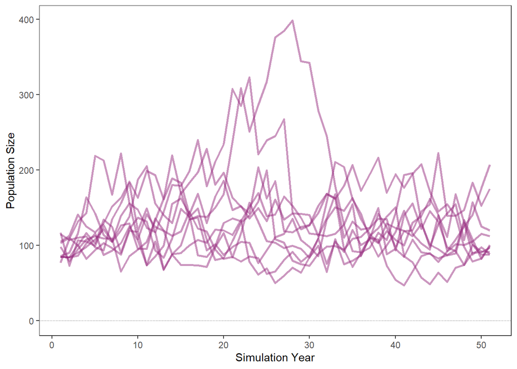

```r
library(ggplot2)
library(viridis)

#-------------------------------------------#
# GENERATE AND STORE YEAR-SPECIFIC MATRICES #
#-------------------------------------------#

## Load dataframe of posterior summaries
post.sum <- readRDS("Files_ArcticFox/ArcticFoxIPM_PosteriorSummary.rds")

## Convert into vector of medians
post.median <- post.sum$Median
names(post.median) <- post.sum$Parameter

## Set maximum time-step in data
Tmax <- 23

## Prepare an array to store projection matrices
mat.Y <- array(0, dim = c(5, 5, Tmax-1))

## Prepare a matrix to store initial population sizes
N0.Y <- matrix(NA, nrow = 5, ncol = Tmax-1)

## Prepare a vector to store immigrant numbers
Imm.Y <- rep(NA, Tmax-1)

## Extract year-specific matrices and population sizes based on posterior means
for(t in 1:(Tmax-1)){

    # Extract vital rates
    Sj <- exp(-(post.median[paste("mH[2, ", t, "]", sep = "")] + post.median[paste("mO[2, ", t, "]", sep = "")]))
    Sa <- exp(-(post.median[paste("mH[1, ", t, "]", sep = "")] + post.median[paste("mO[1, ", t, "]", sep = "")]))

    Psi2 <- post.median[paste("Psi[2, ", t+1, "]", sep = "")]
    Psi3 <- post.median[paste("Psi[3, ", t+1, "]", sep = "")]
    Psi4 <- post.median[paste("Psi[4, ", t+1, "]", sep = "")]
    Psi5 <- post.median[paste("Psi[5, ", t+1, "]", sep = "")]

    rho2 <- post.median[paste("rho[2, ", t+1, "]", sep = "")]
    rho3 <- post.median[paste("rho[3, ", t+1, "]", sep = "")]
    rho4 <- post.median[paste("rho[4, ", t+1, "]", sep = "")]
    rho5 <- post.median[paste("rho[5, ", t+1, "]", sep = "")]

    S0 <- exp(-post.median[paste("m0t[", t+1, "]", sep = "")])


    # Write projection matrix
    mat.Y[1, 1, t] <- Sj*0.5*Psi2*rho2*S0
    mat.Y[1, 2, t] <- Sa*0.5*Psi3*rho3*S0
    mat.Y[1, 3, t] <- Sa*0.5*Psi4*rho4*S0
    mat.Y[1, 4, t] <- Sa*0.5*Psi5*rho5*S0
    mat.Y[1, 5, t] <- Sa*0.5*Psi5*rho5*S0

    mat.Y[2, 1, t] <- Sj

    mat.Y[3, 2, t] <- Sa

    mat.Y[4, 3, t] <- Sa

    mat.Y[5, 4, t] <- Sa
    mat.Y[5, 5, t] <- Sa


    # Extract starting population size
    N0.Y[1, t] <- post.median[paste("N[1, ", t, "]", sep = "")]
    N0.Y[2, t] <- post.median[paste("N[2, ", t, "]", sep = "")]
    N0.Y[3, t] <- post.median[paste("N[3, ", t, "]", sep = "")]
    N0.Y[4, t] <- post.median[paste("N[4, ", t, "]", sep = "")]
    N0.Y[5, t] <- post.median[paste("N[5, ", t, "]", sep = "")]

    # Extract immigrant numbers
    Imm.Y[t] <- post.median[paste("Imm[", t+1, "]", sep = "")]
}


#--------------------------------------------------------------------------#
# FUNCTION FOR STOCHASTIC PROJECTION USING A PRE-DEFINED SEQUENCE OF YEARS #
#--------------------------------------------------------------------------#

stoch.Proj = function(YearSeq){

    # Determine projection length
    Tmax <- length(YearSeq)

    # Make population vector
    N <- matrix(NA, nrow = 5, ncol = Tmax+1)

    # Set starting population size
    N[,1] <- N0.Y[,YearSeq[1]]

    # Project population
    for(t in 1:Tmax){

        N[,t+1] <- (mat.Y[,,YearSeq[t]]%*%N[,t]) + c(Imm.Y[YearSeq[t]], 0, 0, 0, 0)
    }

    return(N)
}

#--------------------------------------------------------------------------#
# FUNCTION TO RUN A SERIES OF PROJECTIONS AND RETURN RESULTS AS DATA FRAME #
#--------------------------------------------------------------------------#

stoch.Sims = function(i, data.Tmax, sim.Tmax){ # i = simulation number

    # Make a random sequence of years
    YearSeq <- sample(c(1:(data.Tmax-1)), sim.Tmax, replace = T)

    # Population projection
    N <- stoch.Proj(YearSeq)

    # Arrange projection results in a data frame
    output <- data.frame(
    SimNo = i,
    SimYear = c(1:(length(YearSeq)+1)),
    Ntot = colSums(N),
    N1 = N[1,],
    N2 = N[2,],
    N3 = N[3,],
    N4 = N[4,],
    N5 = N[5,],
    p1 = N[1,]/colSums(N),
    p2 = N[2,]/colSums(N),
    p3 = N[3,]/colSums(N),
    p4 = N[4,]/colSums(N),
    p5 = N[5,]/colSums(N)
    )

    # Return results
    return(output)
}


#------------------------------------------#
# RUNNING SIMULATIONS AND PLOTTING RESULTS #
#------------------------------------------#

## Set number of replicates to simulate
SimNoMax <- 10

## Set number of years to simulate for
SimYearMax <- 50

## Running simulations
sim.results <- do.call("rbind", sapply(1:SimNoMax, FUN = function(i) stoch.Sims(i, data.Tmax = 23, sim.Tmax = SimYearMax), simplify = FALSE))

## Plot simulations over time

# Total population size
ggplot(sim.results, aes(x = SimYear, y = Ntot, group = SimNo)) + geom_line(color = magma(8)[4], alpha = 0.5, linewidth = 1) + geom_hline(aes(yintercept = 0), linetype = 'dotted', linewidth = 0.3) + ylab('Population Size') + xlab('Simulation Year') + theme_bw() + theme(panel.grid = element_blank())
```

## 4) Simplified prediction- and matrix functions

The code above is from Nater et al.’s original work. The vital rate prediction function was aimed at predicting over the entire range of only one covariate at a time, and the matrix projection directly uses the time-specific vital rate estimates from the run IPM. Neither are ideal for the specific application here. For that reason, we write alternative functions for predicting vital rates based on environmental conditions and collating them into projection matrices.

### 4.1) Vital rate functions

First, we’ll define functions for calculating the different vital rates based on specific values of standardized and de-trended environmental covariates (reindeer carcass availability, sea ice extent, and goose abundance). Note that most vital rates were estimated including linear time trends and random year effects in addition. The functions below are set up in a way that they will make calculations based on the average year in the time series and with a random effect of 0 when year and random effect are not specified, and use specified years and/or random effects when these are specified.

Here’s how this looks for pregnancy rate:

```r
## Predicting pregnancy rate (Psi)
Psi.predict <- function(par.a, par.b, par.c,
                        betaRC.Psi, betaSI.Psi,
                        betaY.Psi, epsilon.Psi = 0,
                        age,
                        reindeerCov, seaIceCov,
                        year = 2008){

  # Determine year index
  yearIdx <- year - 1997 + 1

  # Calculate linear predictor on link scale
  logit.eta <- par.b*(par.c - age) + betaY.Psi*(yearIdx-12) + betaRC.Psi*reindeerCov + betaSI.Psi*seaIceCov + epsilon.Psi

  # Back-calculate & return
  eta <- boot::inv.logit(logit.eta)
  Psi <- par.a*eta

  return(Psi)
}

## Demonstration (using average year and no random effects)
Psi.predict(par.a = median(MCMC.mat[,"par.a"]),
            par.b = median(MCMC.mat[,"par.b"]),
            par.c = median(MCMC.mat[,"par.c"]),
            betaRC.Psi = median(MCMC.mat[,"betaRC.Psi"]),
            betaSI.Psi = median(MCMC.mat[,"betaSI.Psi"]),
            betaY.Psi = median(MCMC.mat[,"betaY.Psi"]),
            age = 4,
            reindeerCov = 0, seaIceCov = 0)
```

```
## [1] 0.7593832
```

```r
## Demonstration (using a specific year and corresponding random effect)
test.year <- 2015
test.year.idx <- test.year - 1997 + 1 # year index used in IPM
RE.name <- paste0("epsilon.Psi[", test.year.idx, "]") # parameter name for corresponding random effect

Psi.predict(par.a = median(MCMC.mat[,"par.a"]),
            par.b = median(MCMC.mat[,"par.b"]),
            par.c = median(MCMC.mat[,"par.c"]),
            betaRC.Psi = median(MCMC.mat[,"betaRC.Psi"]),
            betaSI.Psi = median(MCMC.mat[,"betaSI.Psi"]),
            betaY.Psi = median(MCMC.mat[,"betaY.Psi"]),
            epsilon.Psi = median(MCMC.mat[,RE.name]),
            age = 4,
            reindeerCov = 0, seaIceCov = 0,
            year = test.year)
```

```
## [1] 0.8094195
```

So if we wanted to retrieve the actual Psi for a specific year, we could now specify the year, the corresponding random effect, and also pass the observed covariate effects from that specific year (contained in ArcticFoxIPM_EnvCov.rds).

We can specify similar functions for all other vital rates too:

```r
## Predicting litter size (rho)
rho.predict <- function(mean.rho, a.eff1,
                        betaRC.rho, betaSI.rho,
                        betaY.rho, epsilon.rho = 0,
                        age,
                        reindeerCov, seaIceCov,
                        year = 2008){

  # Determine year index
  yearIdx <- year - 1997 + 1

  # Calculate linear predictor on link scale
  log.rho <- log(mean.rho) + a.eff1*age + betaY.rho*(yearIdx-12) + betaSI.rho*seaIceCov + betaRC.rho*reindeerCov + epsilon.rho

  # Back-calculate & return
  rho <- exp(log.rho)

  return(rho)
}

## Predicting denning survival
S0.predict <- function(S0,
                       betaRC.m0, betaSI.m0,
                       betaY.m0, epsilon.m0 = 0,
                       reindeerCov, seaIceCov,
                       year = 2008){

  # Determine year index
  yearIdx <- year - 1997 + 1

  # Calculate linear predictor on link scale (log hazard rate)
  log.m0 <- log(-log(S0)) + betaY.m0*(yearIdx-12) + betaRC.m0*reindeerCov + betaSI.m0*seaIceCov + epsilon.m0

  # Back-calculate & return
  m0 <- exp(log.m0) # mortality hazard rate
  S0 <- exp(-m0) # survival probability

  return(m0)
}

## Predicting annual survival (juveniles and adults)
S.predict <- function(Mu.mH_j, Mu.mH_a, Mu.mO_j, Mu.mO_a,
                      betaRC.mO, betaSI.mO, betaG.mO,
                      betaHP.mH, betaY.mO,
                      epsilon.mO = 0, epsilon.mH = 0,
                      reindeerCov, seaIceCov, gooseCov,
                      year = 2008, HuntingLevel){

  # Determine year index
  yearIdx <- year - 1997 + 1

  # Make variable HPeriod based on "HuntingLevel"
  if(HuntingLevel %in% 1:2){
    HPeriod <- HuntingLevel - 1
  }else{
    stop("Invalid HuntingLevel provided. Set to either 1 (first period, higher hunting pressure) or 2 (second period, lower hunting pressure).")
  }

  # Calculate linear predictors on link scale (log hazard rates)

  # Hunting mortality
  log.mH <- c(log(Mu.mH_j) + betaHP.mH*HPeriod + epsilon.mH, # Juveniles
              log(Mu.mH_a) + betaHP.mH*HPeriod + epsilon.mH) # Adults

  # Natural mortality
  log.mO <- c(log(Mu.mO_j) + betaY.mO*(yearIdx-12) + betaRC.mO*reindeerCov + betaG.mO*gooseCov + betaSI.mO*seaIceCov + epsilon.mO, # Juveniles
              log(Mu.mO_a) + betaY.mO*(yearIdx-12) + betaRC.mO*reindeerCov + betaSI.mO*seaIceCov + epsilon.mO) # Adults


  # Back-calculate & return
  mH <- exp(log.mH) # Hunting mortality hazard rate
  mO <- exp(log.mO) # Natural mortality hazard rate
  S <- exp(-(mH + mO)) # Survival probability
  names(S) <- c("Juveniles", "Adults")

  return(S)
}
```

The function for predicting survival (`S.predict`) has a few more inputs than the others because it calculates four mortality hazard rates (hunting and natural mortality of juveniles and adults) and derives annual survival from them. Natural mortality is modeled as a function of environmental covariates (reindeer carcasses and sea ice for both age classes, and geese additionally for the juveniles). Hunting mortality was estimated for two separate periods of time. If you set the argument `HuntingLevel` to 1, you will get estimates for the first period, which had higher hunting pressure, and if you set it to 2, you will get estimates for the second period, which had lower hunting pressure. Unlike the other functions, this one returns a vector with two elements corresponding to juvenile and adult annual survival:

```r
## Period with more hunting
S.predict(Mu.mH_j = median(MCMC.mat[,"Mu.mH[2]"]),
          Mu.mH_a = median(MCMC.mat[,"Mu.mH[1]"]),
          Mu.mO_j = median(MCMC.mat[,"Mu.mO[2]"]),
          Mu.mO_a = median(MCMC.mat[,"Mu.mO[1]"]),
          betaRC.mO = median(MCMC.mat[,"betaRC.mO"]),
          betaSI.mO = median(MCMC.mat[,"betaSI.mO"]),
          betaG.mO = median(MCMC.mat[,"betaG.mO"]),
          betaHP.mH = median(MCMC.mat[,"betaHP.mH"]),
          betaY.mO = median(MCMC.mat[,"betaY.mO"]),
          reindeerCov = 0, seaIceCov = 0, gooseCov = 0,
          HuntingLevel = 1)
```

```
## Juveniles    Adults
## 0.3593180 0.4971019
```

```r
## Period with less hunting
S.predict(Mu.mH_j = median(MCMC.mat[,"Mu.mH[2]"]),
          Mu.mH_a = median(MCMC.mat[,"Mu.mH[1]"]),
          Mu.mO_j = median(MCMC.mat[,"Mu.mO[2]"]),
          Mu.mO_a = median(MCMC.mat[,"Mu.mO[1]"]),
          betaRC.mO = median(MCMC.mat[,"betaRC.mO"]),
          betaSI.mO = median(MCMC.mat[,"betaSI.mO"]),
          betaG.mO = median(MCMC.mat[,"betaG.mO"]),
          betaHP.mH = median(MCMC.mat[,"betaHP.mH"]),
          betaY.mO = median(MCMC.mat[,"betaY.mO"]),
          reindeerCov = 0, seaIceCov = 0, gooseCov = 0,
          HuntingLevel = 2)
```

```
## Juveniles    Adults
## 0.4090584 0.5567268
```

The relationship between survival probability (S) and hunting and natural mortality (mH and mO) is given as: S = exp(-(mH + mO)). This may matter for your sensitivity calulations.

### 4.2) Projection matrix assembly

Next, we define a function for assembling the projection matrix from the vital rates we have calculated using the prediction functions above:

```r
assemble.arcticFoxMPM <- function(S0, Sj, Sa,
                                  Psi2, Psi3, Psi4, Psi5,
                                  rho2, rho3, rho4, rho5){

  # Set number of stages
  n.stage <- 5

  # Assemble and return projection matrix
  mpm <- matrix(c(Sj*0.5*Psi2*rho2*S0, Sj, 0, 0, 0,
                  Sa*0.5*Psi3*rho3*S0, 0, Sa, 0, 0,
                  Sa*0.5*Psi4*rho4*S0, 0, 0, Sa, 0,
                  Sa*0.5*Psi5*rho5*S0, 0, 0, 0, Sa,
                  Sa*0.5*Psi5*rho5*S0, 0, 0, 0, Sa),
                  nrow = n.stage, ncol = n.stage)
  return(mpm)
}
```

For convenience, we may now want to combine vital rate prediction and matrix assembly into yet one more function (a “wrapper” function). Like so:

```r
make.arcticFoxMPM <- function(reindeerCov, seaIceCov, gooseCov,
                              year = 2008, HuntingLevel,
                              randomEff,
                              epsilon.Psi = 0,
                              epsilon.rho = 0,
                              epsilon.m0 = 0,
                              epsilon.mH = 0,
                              epsilon.mO = 0
                              ){

  ## Define random effect levels based on argument "randomEff"
  if(randomEff == "match"){
     yearIdx <- year - 1997 + 1
     epsilon.Psi.use <- median(MCMC.mat[, paste0("epsilon.Psi[", yearIdx+1, "]")])
     epsilon.rho.use <- median(MCMC.mat[, paste0("epsilon.rho[", yearIdx+1, "]")])
     epsilon.m0.use <- median(MCMC.mat[, paste0("epsilon.m0[", yearIdx+1, "]")])
     epsilon.mH.use <- median(MCMC.mat[, paste0("epsilon.mH[", yearIdx, "]")])
     epsilon.mO.use <- median(MCMC.mat[, paste0("epsilon.mO[", yearIdx, "]")])
  }

  if(randomEff == "ignore"){
     epsilon.Psi.use <- 0
     epsilon.rho.use <- 0
     epsilon.m0.use <- 0
     epsilon.mH.use <- 0
     epsilon.mO.use <- 0
  }

  if(randomEff == "define"){
     epsilon.Psi.use <- epsilon.Psi
     epsilon.rho.use <- epsilon.rho
     epsilon.m0.use <- epsilon.m0
     epsilon.mH.use <- epsilon.mH
     epsilon.mO.use <- epsilon.mO
  }

  if(!(randomEff %in% c("match", "ignore", "define"))){
    stop("Invalid randomEff option provided. The accepted options are match, ignore, and define.")
  }


  ## Predict vital rates

  # Breeding probability and litter size per age class
  Psi <- rho <- rep(NA, 5)
  for(a in 2:5){
    Psi[a] <- Psi.predict(par.a = median(MCMC.mat[,"par.a"]),
                          par.b = median(MCMC.mat[,"par.b"]),
                          par.c = median(MCMC.mat[,"par.c"]),
                          betaRC.Psi = median(MCMC.mat[,"betaRC.Psi"]),
                          betaSI.Psi = median(MCMC.mat[,"betaSI.Psi"]),
                          betaY.Psi = median(MCMC.mat[,"betaY.Psi"]),
                          epsilon.Psi = epsilon.Psi.use,
                          age = a,
                          reindeerCov = reindeerCov, seaIceCov = seaIceCov,
                          year = year+1)

    rho[a] <- rho.predict(mean.rho = median(MCMC.mat[,"mean.rho"]),
                          a.eff1 = median(MCMC.mat[,"a.eff1"]),
                          betaRC.rho = median(MCMC.mat[,"betaRC.rho"]),
                          betaSI.rho = median(MCMC.mat[,"betaSI.rho"]),
                          betaY.rho = median(MCMC.mat[,"betaY.rho"]),
                          age = a,
                          epsilon.rho = epsilon.rho.use,
                          reindeerCov = reindeerCov, seaIceCov = seaIceCov,
                          year = year+1)
  }

  # Denning survival
  S0 <- S0.predict(S0 = median(MCMC.mat[,"S0"]),
                   betaRC.m0 = median(MCMC.mat[,"betaRC.m0"]),
                   betaSI.m0 = median(MCMC.mat[,"betaSI.m0"]),
                   betaY.m0 = median(MCMC.mat[,"betaY.m0"]),
                   epsilon.m0 = epsilon.m0.use,
                   reindeerCov = reindeerCov, seaIceCov = seaIceCov,
                   year = year+1)

  # Juvenila and adult annual survival
  S <- S.predict(Mu.mH_j = median(MCMC.mat[,"Mu.mH[2]"]),
                 Mu.mH_a = median(MCMC.mat[,"Mu.mH[1]"]),
                 Mu.mO_j = median(MCMC.mat[,"Mu.mO[2]"]),
                 Mu.mO_a = median(MCMC.mat[,"Mu.mO[1]"]),
                 betaRC.mO = median(MCMC.mat[,"betaRC.mO"]),
                 betaSI.mO = median(MCMC.mat[,"betaSI.mO"]),
                 betaG.mO = median(MCMC.mat[,"betaG.mO"]),
                 betaHP.mH = median(MCMC.mat[,"betaHP.mH"]),
                 betaY.mO = median(MCMC.mat[,"betaY.mO"]),
                 epsilon.mH = epsilon.mH.use, epsilon.mO = epsilon.mO.use,
                 reindeerCov = reindeerCov, seaIceCov = reindeerCov, gooseCov = gooseCov,
                 year = year, HuntingLevel = HuntingLevel)

  # List all age-specific vital rates
  VitalRates <- list(S0 = S0, Sj = S[1], Sa = S[2],
                     Psi2 = Psi[2], Psi3 = Psi[3], Psi4 = Psi[4], Psi5 = Psi[5],
                     rho2 = rho[2], rho3 = rho[3], rho4 = rho[4], rho5 = rho[5])


  ## Assemble projection matrix
  MPM <- assemble.arcticFoxMPM(S0 = S0, Sj = S[1], Sa = S[2],
                               Psi2 = Psi[2], Psi3 = Psi[3], Psi4 = Psi[4], Psi5 = Psi[5],
                               rho2 = rho[2], rho3 = rho[3], rho4 = rho[4], rho5 = rho[5])


  ## Return vital rates and MPM
  return(list(VitalRates = VitalRates, MPM = MPM))

}
```

The function above looks quite large, but that is partially because it’s flexible enough to allow different treatments of random effects. This is handled via the `randomEff` argument. There are three options available:

- `randomEff = "ignore"`: all random effects are set to 0
- `randomEff = "match"`: random effects are set to posterior medians of the estimated values for the specified `year`
- `randomEff = "define"`: random effects are set to the numbers specified in the call to `make.arcticFoxMPM`

Besides this, the function also requires provision of values for the three environmental covariates and setting of the `HuntingLevel` to either 1 or 2. Optionally, you can also specify the year (default otherwise = 2008, the middle year in the data time series). The function then returns a list with two element: a list of vital rate values and a projection matrix

```r
make.arcticFoxMPM(reindeerCov = 0, seaIceCov = 0, gooseCov = 0,
                  year = 2012, HuntingLevel = 2,
                  randomEff = "ignore")
```

```
## $VitalRates
## $VitalRates$S0
## [1] 0.3361428
##
## $VitalRates$Sj
## Juveniles
## 0.4078924
##
## $VitalRates$Sa
##    Adults
## 0.5557479
##
## $VitalRates$Psi2
## [1] 0.05981897
##
## $VitalRates$Psi3
## [1] 0.3751107
##
## $VitalRates$Psi4
## [1] 0.8094612
##
## $VitalRates$Psi5
## [1] 0.9176348
##
## $VitalRates$rho2
## [1] 4.991076
##
## $VitalRates$rho3
## [1] 5.39745
##
## $VitalRates$rho4
## [1] 5.836911
##
## $VitalRates$rho5
## [1] 6.312154
##
##
## $MPM
##            [,1]      [,2]      [,3]      [,4]      [,5]
## [1,] 0.02046786 0.1891123 0.4413170 0.5410271 0.5410271
## [2,] 0.40789240 0.0000000 0.0000000 0.0000000 0.0000000
## [3,] 0.00000000 0.5557479 0.0000000 0.0000000 0.0000000
## [4,] 0.00000000 0.0000000 0.5557479 0.0000000 0.0000000
## [5,] 0.00000000 0.0000000 0.0000000 0.5557479 0.5557479
```

IMPORTANT: Note that for creating the projection matrix for a specific time interval $t$ to $t+1$ (using observed or simulated time-series of environmental covariates), the reindeer and sea ice covariate values for year $t+1$ have to be passed. This is because the census is June-May, and these are winter covariates. Goose abundance, on the other hand, is a summer covariate and has to be passed with time index $t$.

### 4.3) Additional remarks

The projection matrix assembled above is very likely to give low population growth rates (< 1) because it does not include the immigration part of the system. Nater et. al estimated the annual number of immigrants under the assumption that all immigrants are juveniles. So for including immigration, you would have to add a number of immigrants to the juvenile age class at each census. Immigrant numbers can be simulated using posterior estimates from the integrated population model too and follow a normal distribution with mean `avgImm` and standard deviation `sigma.imm`:

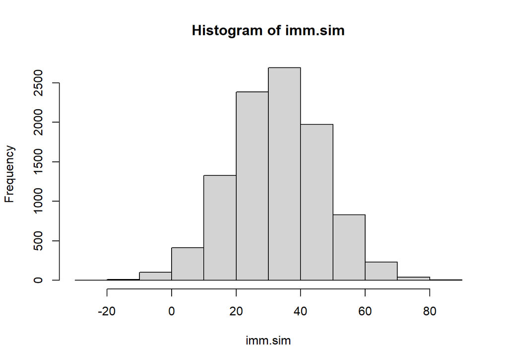

```r
imm.sim <- rnorm(10000, mean = median(MCMC.mat[,"avgImm"]), sd = median(MCMC.mat[,"sigma.Imm"]))
hist(imm.sim)
```

Notably, this may give you negative values (which should not be possible). To avoid this, you can use a truncated normal distrbution instead.

## 5) Scaled sensitivity analyses

Here, we calculate scaled sensitivities, according to Morris et al. 2020 (DOI: https://doi.org/10.1073/pnas.1918363117)

Note that this is a step that Esin will implement in her MS thesis. With the information given in 1-3, we should be able to run these analyses.

## 6) Sensitivity analyses at equilibrium dynamics

Here, we perform “classic” sensitivity analyses (see Paniw et al. 2019; DOI: 10.1126/science.aau5905)

1. We look for combinations of covariate values where lambda approaches 1
2. We perturb each covariate for each vital rate in turn, while maintaining the other covariates at values that would ensure stable population dynamics. A perturbation entails a 10 % increase in a covariate.
3. Plot the sensitivities